# Exploratory Data Analysis on New York Air Quality Dataset

Arjun Dutta

31 Jan 2018

# *A. About the Dataset*

## **Data Set**

New York Air Quality Measurements

## **Description**

Daily air quality measurements in New York, May to September 1973.

## **Format**

A data frame with 153 observations on 6 variables.

- **Ozone :** numeric Ozone (ppb)
- **Solar.R :** numeric Solar R (lang)
- **Wind :** numeric Wind (mph)
- **Temp :** numeric Temperature (degrees F)
- **Month :** numeric Month (1–12)
- **Day :** numeric Day of month (1–31)

## **Details**

Daily readings of the following air quality values for May 1, 1973 (a Tuesday) to September 30, 1973.

- **Ozone:** Mean ozone in parts per billion from 1300 to 1500 hours at Roosevelt Island
- **Solar.R:** Solar radiation in Langleys in the frequency band 4000-7700 Angstroms from 0800 to 1200 hours at Central Park
- **Wind:** Average wind speed in miles per hour at 0700 and 1000 hours at LaGuardia Airport
- **Temp:** Maximum daily temperature in degrees Fahrenheit at La Guardia Airport.

## **Source:**

The data were obtained from the New York State Department of Conservation (**ozone data**) and the National Weather Service (**meteorological data**).

# *B. Analyzing the Structure of the Data*

```r
#Packages Deployed
load.libraries <- c('e1071','dplyr','datasets','VIM','mice')
#if not present identify and download
install.lib <- load.libraries[!load.libraries %in% installed.packages()]
sapply(install.lib, install.packages,repos = "http://cran.us.r-project.org")
#Load the packages
sapply(load.libraries, require, character = TRUE)
```

Here we show the Data Structure of the dataset using the **class()** function, Dimension of the dataset by **dim()** and Data types of each variable by using **glimpse()** function from **base** and **dplyr** packages in R.Next identify the data type and category of the variables.

## **DataStructure**

```r
#Data Structure of the Dataset
class(airquality)
```

```
[1] "data.frame"
```

## **Dimension**

```r
#Dimension of the Dataset
dim(airquality)
```

```
[1] 153   6
```

## **Data Types**

```r
#Data Type of Each Variable in the Dataset
glimpse(airquality)
```

```
Observations: 153
Variables: 6
$ Ozone   <int> 41, 36, 12, 18, NA, 28, 23, 19, 8, NA, 7, 16, 11, 14, ...
$ Solar.R <int> 190, 118, 149, 313, NA, NA, 299, 99, 19, 194, NA, 256,...
$ Wind    <dbl> 7.4, 8.0, 12.6, 11.5, 14.3, 14.9, 8.6, 13.8, 20.1, 8.6...
$ Temp    <int> 67, 72, 74, 62, 56, 66, 65, 59, 61, 69, 74, 69, 66, 68...
$ Month   <int> 5, 5, 5, 5, 5, 5, 5, 5, 5, 5, 5, 5, 5, 5, 5, 5, 5, 5, ...
$ Day     <int> 1, 2, 3, 4, 5, 6, 7, 8, 9, 10, 11, 12, 13, 14, 15, 16,...
```

The Data Structure of the dataset is a dataframe with Dimension of 153 rows and 6 columns and Data types are **int** and **dbl** i.e. integer and double(numeric) respectively.

## **Category of the Variable**

The variable with **int** and **dbl** data type are of the format of continuous variable.

# *C. Outlier Detection and Treatment*

## **Outliers**

For a given continuous variable, outliers are those observations that lie outside 1.5 * IQR, where IQR, the ‘Inter Quartile Range’ is the difference between 75th and 25th quartiles.

## **Detecting Outliers**

**Visualization and Mathematical Methods**

For Visualization Methods Boxplot with range 1.5 and Histogram with break 15 is used to get a clear idea about the data. Quantile Capping Method is used to detect the outliers(Mathematically) in the data for each variable after Visualization.

```r
#This function detects Outliers by quantile capping method
outdetect <- function(c,w=1.5)
{
  h <- w*IQR(c,na.rm = T)
  q <- quantile(c,probs=c(.25, .75),na.rm = T)
  if(length(which(q[1]-h>c))==0)
    cat("There are",sum(q[1]-h>c,na.rm = T),"observations below the 1st quantile\n")
  else
    cat("There are",sum(q[1]-h>c,na.rm = T),"observations below the 1st quantile","on rows",which(q[1]-h>c),"and the values are",boxplot.stats(c)$out,"\n")
  if(length(which(q[2]+h<c))==0)
    cat("There are",sum(q[2]+h<c,na.rm = T),"observations above the 3rd quantile\n")
  else
    cat("There are",sum(q[2]+h<c,na.rm = T),"observations above the 3rd quantile","on rows",which(q[2]+h<c),"and the values are",boxplot.stats(c)$out,"\n")
}
```

**Ozone**

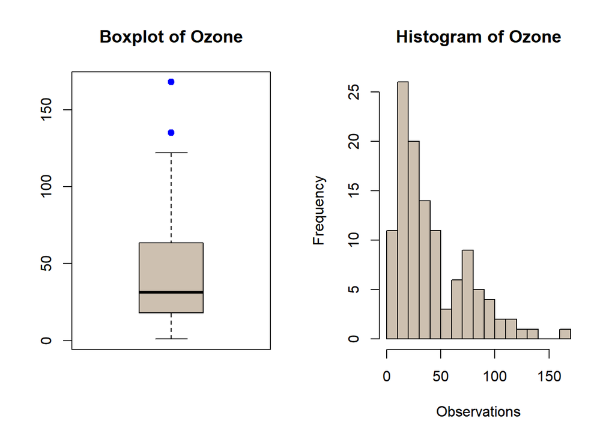

```r
par(mfrow=c(1,2))
boxplot(airquality$Ozone,col = "antiquewhite3",main = "Boxplot of Ozone",outcol="Blue",outpch=19,boxwex=0.7,range = 1.5)
hist(airquality$Ozone,col = "antiquewhite3",main = "Histogram of Ozone", xlab = "Observations",breaks = 15)
```

```r
outdetect(airquality$Ozone)
```

```
There are 0 observations below the 1st quantile
There are 2 observations above the 3rd quantile on rows 62 117 and the values are 135 168
```

**Solar.R**

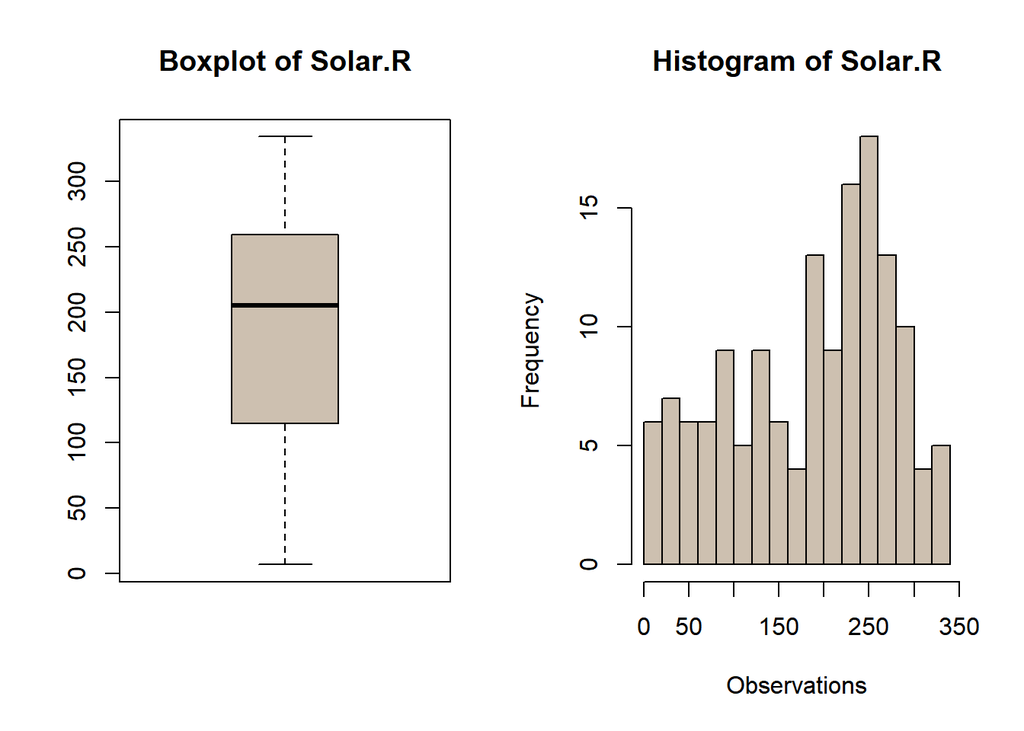

```r
par(mfrow=c(1,2))
boxplot(airquality$Solar.R,col = "antiquewhite3",main = "Boxplot of Solar.R",outcol="Blue",outpch=19,boxwex=0.7,range = 1.5)
hist(airquality$Solar.R,col = "antiquewhite3",main = "Histogram of Solar.R", xlab = "Observations",breaks = 15)
```

```r
outdetect(airquality$Solar.R)
```

```
There are 0 observations below the 1st quantile
There are 0 observations above the 3rd quantile
```

**Wind**

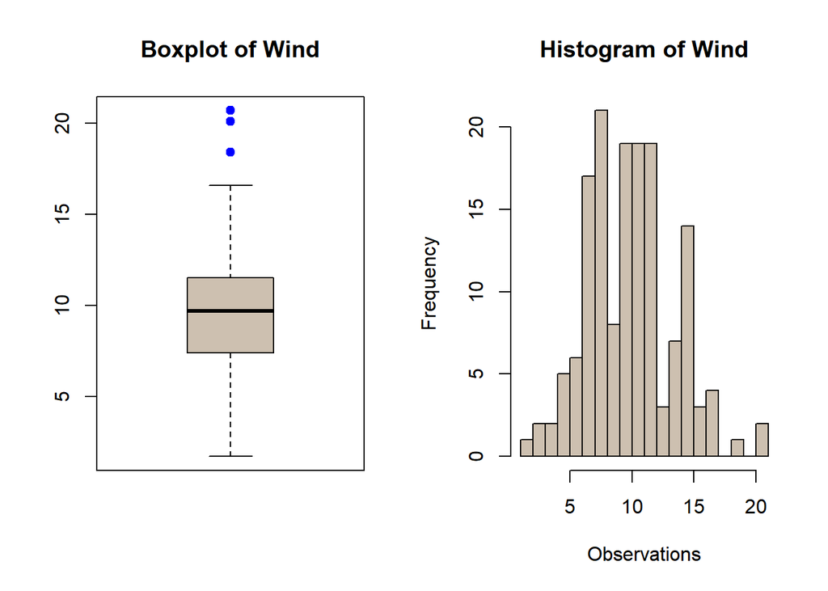

```r
par(mfrow=c(1,2))
boxplot(airquality$Wind,col = "antiquewhite3",main = "Boxplot of Wind",outcol="Blue",outpch=19,boxwex=0.7,range = 1.5)
hist(airquality$Wind,col = "antiquewhite3",main = "Histogram of Wind", xlab = "Observations",breaks = 15)
```

```r
outdetect(airquality$Wind)
```

```
There are 0 observations below the 1st quantile
There are 3 observations above the 3rd quantile on rows 9 18 48 and the values are 20.1 18.4 20.7
```

**Temp**

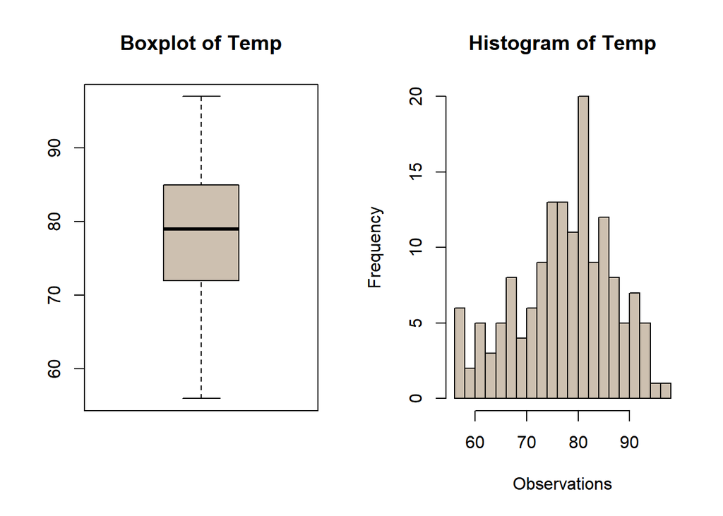

```r
par(mfrow=c(1,2))
boxplot(airquality$Temp,col = "antiquewhite3",main = "Boxplot of Temp",outcol="Blue",outpch=19,boxwex=0.7,range = 1.5)
hist(airquality$Temp,col = "antiquewhite3",main = "Histogram of Temp", xlab = "Observations",breaks = 15)
```

```r
outdetect(airquality$Temp)
```

```
There are 0 observations below the 1st quantile
There are 0 observations above the 3rd quantile
```

From the Above Boxplots we can see that in Ozone and Wind Variables there are **Outliers**(the blue dots). Also on Histogram of both the variables Ozone and Wind we can see that there is a gap between observations at extreme i.e. In Ozone Histogram there is one gap in the chart and in Wind Histogram there are two gaps in chart, so they are Outliers.

## **Outliers Treatment**

Since the number of outliers in the dataset is very small the best approach is to remove them and carry on with the analysis but capping method can also be used. Percentile Capping is a method of imputing the outlier values by replacing those observations outside the lower limit with the value of 5th percentile and those that lie above the upper limit, with the value of 95th percentile of the same dataset.

```r
outcap <- function(x)
{
qnt <- quantile(x, probs=c(.25, .75), na.rm = T)
caps <- quantile(x, probs=c(.05, .95), na.rm = T)
H <- 1.5 * IQR(x, na.rm = T)
sum(x > (qnt[2] + H))
x[x < (qnt[1] - H)] <- caps[1]
x[x > (qnt[2] + H)] <- caps[2]
x<<-x
}
```

```r
Data <- airquality
outcap(Data$Ozone)
Data$Ozone <- x
outcap(Data$Wind)
Data$Wind <- x
Data[c(9,18,48,62,117),c(1,3)]
```

|  | Ozone | Wind |
| --- | --- | --- |
| 9 | 8.0 | 15.5 |
| 18 | 6.0 | 15.5 |
| 48 | 37.0 | 15.5 |
| 62 | 108.5 | 4.1 |
| 117 | 108.5 | 3.4 |

Now check the 9th, 18th and 48th value of Wind and 62nd 117th value of Ozone variable the Varibles are free of Outliers so we move to treat Missing Values.

# *D. Missing Value Detection and Treatment*

## **Missing Values**

Missing data in the training data set can reduce the power / fit of a model or can lead to a biased model because we have not analysed the behavior and relationship with other variables correctly. It can lead to wrong prediction or classification.

## **Detecting Missing Values**

**Mathematical Methods**

To check for **Missing Value** call the **summary()** on the dataset.

**Summary of the Data**

```r
#Summary of the Data
summary(Data[-c(5,6)])
```

```
     Ozone           Solar.R           Wind             Temp
 Min.   :  1.00   Min.   :  7.0   Min.   : 1.700   Min.   :56.00
 1st Qu.: 18.00   1st Qu.:115.8   1st Qu.: 7.400   1st Qu.:72.00
 Median : 31.50   Median :205.0   Median : 9.700   Median :79.00
 Mean   : 41.39   Mean   :185.9   Mean   : 9.875   Mean   :77.88
 3rd Qu.: 63.25   3rd Qu.:258.8   3rd Qu.:11.500   3rd Qu.:85.00
 Max.   :122.00   Max.   :334.0   Max.   :16.600   Max.   :97.00
 NA's   :37       NA's   :7
```

See that on Ozone there are 37 NA’s and on Solar.R there are 7 NA’s.

**Names of the Columns which contains Missing Values**

```r
#Names of the Variables which contains Missing Values
colnames(Data)[colSums(is.na(Data)) > 0]
```

```
[1] "Ozone"   "Solar.R"
```

**Percentage of Columns and Rows which contains Missing Values**

Assuming the data is **Missing Completly At Random**, too much missing data can be a problem too. A safe maximum threshold is 5% of the total for large datasets. If missing data for a certain Variable is more than 5% then leave that Variable out. Let’s check the columns and rows where more than 5% of the data is missing using a simple function :-

```r
PerMiss <- function(x){sum(is.na(x))/length(x)*100}
```

**Columns**

```r
apply(Data[c(1,2)],2,PerMiss)
```

```
    Ozone   Solar.R
24.183007  4.575163
```

**Rows**

```r
apply(Data,1,PerMiss)
```

```
  [1]  0.00000  0.00000  0.00000  0.00000 33.33333 16.66667  0.00000
  [8]  0.00000  0.00000 16.66667 16.66667  0.00000  0.00000  0.00000
 [15]  0.00000  0.00000  0.00000  0.00000  0.00000  0.00000  0.00000
 [22]  0.00000  0.00000  0.00000 16.66667 16.66667 33.33333  0.00000
 [29]  0.00000  0.00000  0.00000 16.66667 16.66667 16.66667 16.66667
 [36] 16.66667 16.66667  0.00000 16.66667  0.00000  0.00000 16.66667
 [43] 16.66667  0.00000 16.66667 16.66667  0.00000  0.00000  0.00000
 [50]  0.00000  0.00000 16.66667 16.66667 16.66667 16.66667 16.66667
 [57] 16.66667 16.66667 16.66667 16.66667 16.66667  0.00000  0.00000
 [64]  0.00000 16.66667  0.00000  0.00000  0.00000  0.00000  0.00000
 [71]  0.00000 16.66667  0.00000  0.00000 16.66667  0.00000  0.00000
 [78]  0.00000  0.00000  0.00000  0.00000  0.00000 16.66667 16.66667
 [85]  0.00000  0.00000  0.00000  0.00000  0.00000  0.00000  0.00000
 [92]  0.00000  0.00000  0.00000  0.00000 16.66667 16.66667 16.66667
 [99]  0.00000  0.00000  0.00000 16.66667 16.66667  0.00000  0.00000
[106]  0.00000 16.66667  0.00000  0.00000  0.00000  0.00000  0.00000
[113]  0.00000  0.00000 16.66667  0.00000  0.00000  0.00000 16.66667
[120]  0.00000  0.00000  0.00000  0.00000  0.00000  0.00000  0.00000
[127]  0.00000  0.00000  0.00000  0.00000  0.00000  0.00000  0.00000
[134]  0.00000  0.00000  0.00000  0.00000  0.00000  0.00000  0.00000
[141]  0.00000  0.00000  0.00000  0.00000  0.00000  0.00000  0.00000
[148]  0.00000  0.00000 16.66667  0.00000  0.00000  0.00000
```

**Patterns and Visualizations of Missing Values**

The mice package provides a nice function md.pattern() to get a better understanding of the pattern of missing data. **Patterns**

```r
library(mice)
md.pattern(Data)
```

```
    Wind Temp Month Day Solar.R Ozone
111    1    1     1   1       1     1  0
 35    1    1     1   1       1     0  1
  5    1    1     1   1       0     1  1
  2    1    1     1   1       0     0  2
       0    0     0   0       7    37 44
```

A perhaps more helpful visual representation can be obtained using the VIM package as follows

**Visualizations**

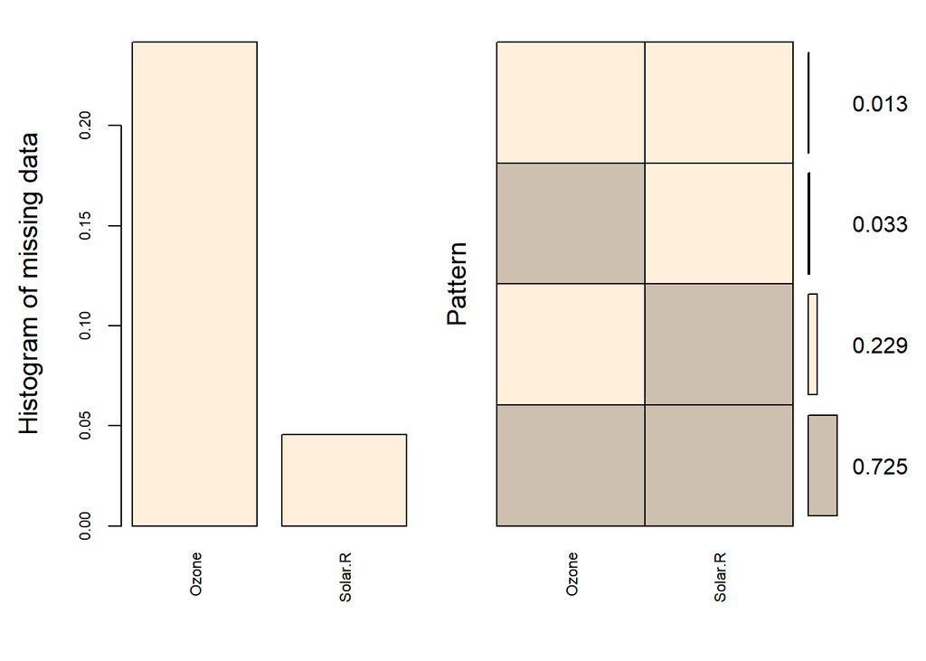

```
 Variables sorted by number of missings:
 Variable      Count
    Ozone 0.24183007
  Solar.R 0.04575163
```

```r
library(VIM)
aggr_plot <-  aggr(Data[c(1,2)], col=c('antiquewhite3','antiquewhite1'), numbers=TRUE, sortVars=TRUE, labels=names(Data[c(1,2)]), cex.axis=.7, gap=3, ylab=c("Histogram of missing data","Pattern"))
```

The plot helps us understanding that almost 72% of the samples are not missing any information, 24% are missing the Ozone value, and the remaining ones show other missing patterns. Through this approach the situation looks a bit clearer in my opinion.

Another helpful visual approach is a special box plot

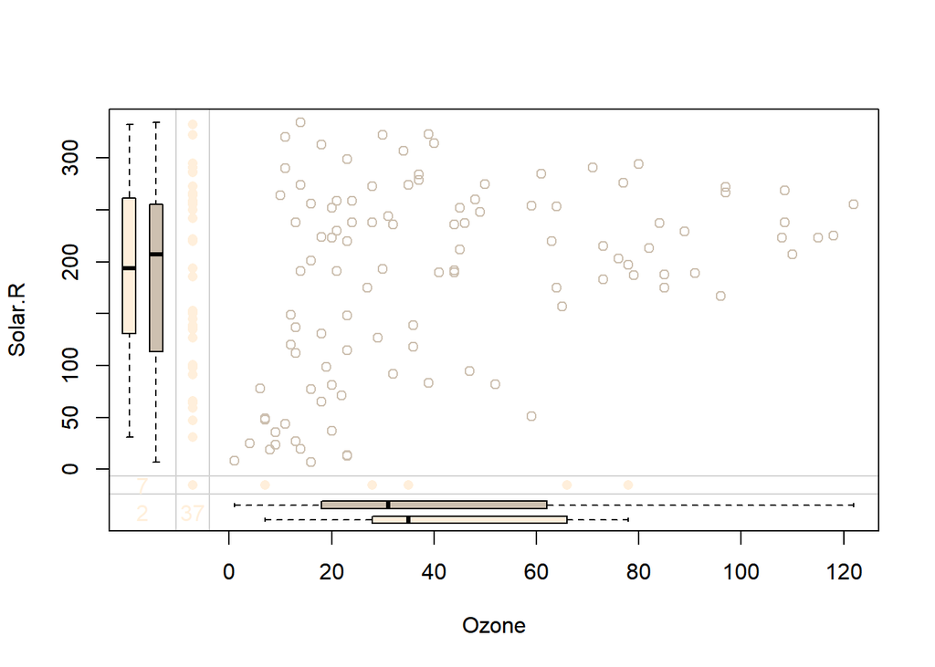

```r
marginplot(Data[c(1,2)], col=c('antiquewhite3','antiquewhite1'))
```

## **Missing Value Treatment**

The mice() function takes care of the imputing process.PMM (Predictive Mean Matching) - technique is used because it is suitable for numeric variables.

```r
tempData <- mice(Data,m=5,maxit=50,meth='pmm',seed=500)
```

**Summary of Missing Values**

```r
summary(tempData)
```

```
Multiply imputed data set
Call:
mice(data = Data, m = 5, method = "pmm", maxit = 50, seed = 500)
Number of multiple imputations:  5
Missing cells per column:
  Ozone Solar.R    Wind    Temp   Month     Day
     37       7       0       0       0       0
Imputation methods:
  Ozone Solar.R    Wind    Temp   Month     Day
  "pmm"   "pmm"   "pmm"   "pmm"   "pmm"   "pmm"
VisitSequence:
  Ozone Solar.R
      1       2
PredictorMatrix:
        Ozone Solar.R Wind Temp Month Day
Ozone       0       1    1    1     1   1
Solar.R     1       0    1    1     1   1
Wind        0       0    0    0     0   0
Temp        0       0    0    0     0   0
Month       0       0    0    0     0   0
Day         0       0    0    0     0   0
Random generator seed value:  500
```

```r
Data <- complete(tempData,1)
```

**Summary of the Dataset(Before Treating Missing Values and Outlier)**

```r
summary(airquality[c(1,2)])
```

```
     Ozone           Solar.R
 Min.   :  1.00   Min.   :  7.0
 1st Qu.: 18.00   1st Qu.:115.8
 Median : 31.50   Median :205.0
 Mean   : 42.13   Mean   :185.9
 3rd Qu.: 63.25   3rd Qu.:258.8
 Max.   :168.00   Max.   :334.0
 NA's   :37       NA's   :7
```

**Summary of the Dataset(after Treating Missing Values and Outlier)**

```r
summary(Data[c(1,2)])
```

```
     Ozone           Solar.R
 Min.   :  1.00   Min.   :  7.0
 1st Qu.: 16.00   1st Qu.:115.0
 Median : 30.00   Median :203.0
 Mean   : 40.15   Mean   :185.3
 3rd Qu.: 59.00   3rd Qu.:258.0
 Max.   :122.00   Max.   :334.0
```

**Conclusions** If we compare the summaries of both the Datasets we can see that the values are not so much deviated from their respective summaries, so we can conclude that taking **Percentile Capping as Outlier Imputation** and **Predictive Mean Matching as Missing Value Imputation** was a right choice.

# *E. Feature Engineering and Analysis*

## **Skewness Transformation**

```r
Viz <- function(x){
  h1 <- hist(x,col="antiquewhite3",main="Histogram",xlab="Variables");
  xfit<-seq(min(x),max(x),length=40)
  yfit<-dnorm(xfit,mean=mean(x),sd=sd(x))
  yfit <- yfit*diff(h1$mids[1:2])*length(x)
  lines(xfit, yfit, col="black", lwd=2)
}
```

### **For Ozone**

**Before Transformation Histogram**

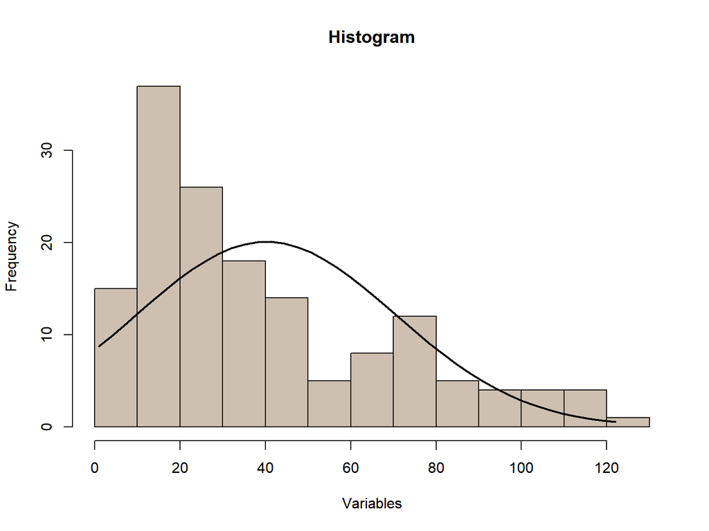

```r
Viz(Data$Ozone)
```

```r
skewness(Data$Ozone)
```

```
[1] 0.9819931
```

The histogram with the density curve of Ozone clearly shows that tail of the distribution lie towards right and thus the variable is Right Skewed.So we need to transform the Variable.

**After Transformation Histogram**

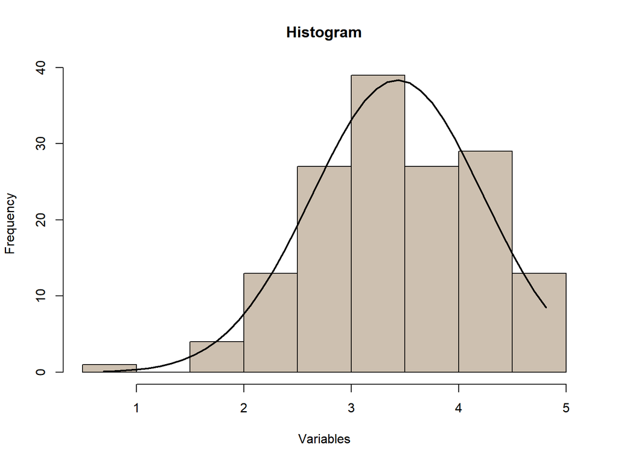

```r
Ozone_T <- log(Data$Ozone+1)
Viz(Ozone_T)
```

```r
skewness(Ozone_T)
```

```
[1] -0.2845094
```

After **Log Transformation** the histogram with the density curve of Ozone clearly shows that maximum frequency of the values lie slightly towards left and thus the variable is nearly skewed and so the data is from normal population. Also the skewness is much close to 0.

**QQPlot**

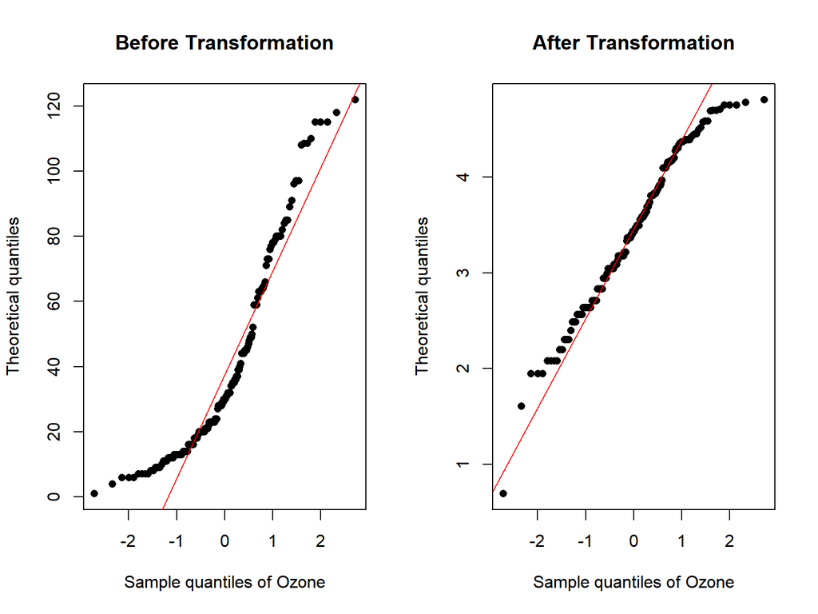

```r
par(mfrow=c(1,2))
qqnorm(Data$Ozone,pch=16,main="Before Transformation",xlab="Sample quantiles of Ozone",ylab="Theoretical quantiles")
qqline(Data$Ozone, col = 2)
qqnorm(log(Data$Ozone+1),pch=16,main="After Transformation",xlab="Sample quantiles of Ozone",ylab="Theoretical quantiles")
qqline(log(Data$Ozone+1), col = 2)
```

**QQPlot** The above QQ plot clearly shows that most of the values lies above the normal line but more or less close to it. So we can interpret that the data is surely from a normal distribution.

**Hypothesis testing:**

```r
shapiro.test(Ozone_T)
```

```
    Shapiro-Wilk normality test

data:  Ozone_T
W = 0.97695, p-value = 0.01139
```

If p is more than .01 {$\alpha$}, we can be 99% {$(1-\alpha)100\%$} certain that the data are normally distributed.

### **For Solar.R**

**Before Transformation Histogram**

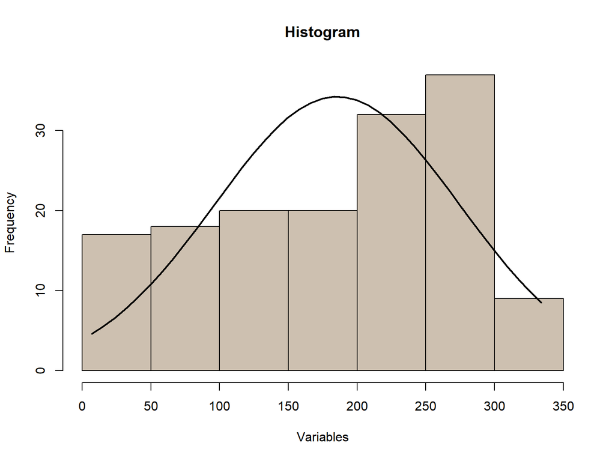

```r
Viz(Data$Solar.R)
```

```r
skewness(Data$Solar.R)
```

```
[1] -0.4044689
```

The histogram with the density curve of Solar.R clearly shows that tail of the distribution lie towards left and thus the variable is Left Skewed.So we need to transform the Variable.

**After Transformation Histogram**

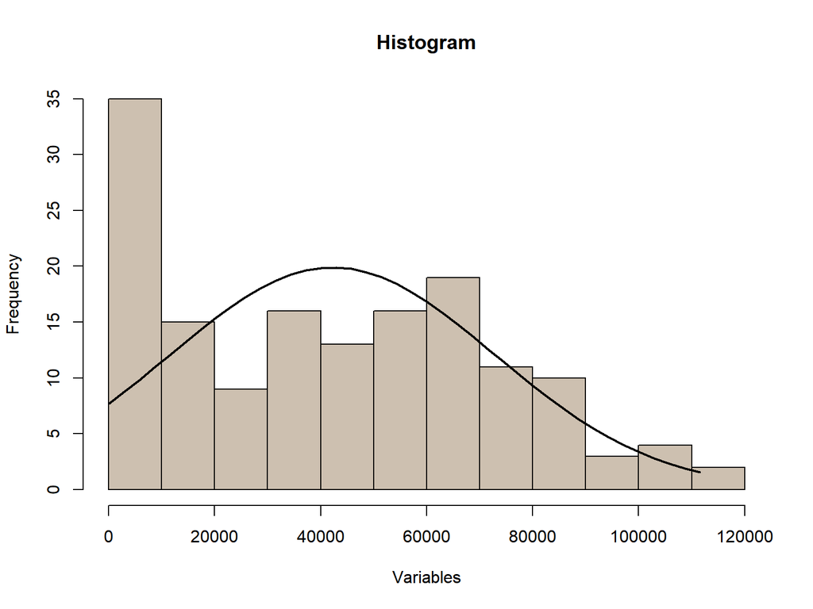

```r
Solar_T <- (Data$Solar.R)^2
Viz(Solar_T)
```

```r
skewness(Solar_T)
```

```
[1] 0.2455632
```

**QQPlot**

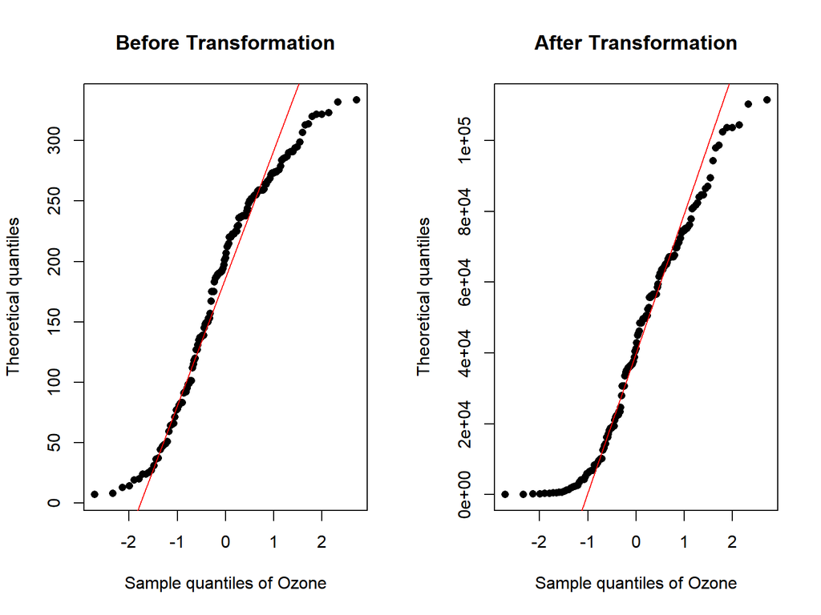

```r
par(mfrow=c(1,2))
qqnorm(Data$Solar.R,pch=16,main="Before Transformation",xlab="Sample quantiles of Ozone",ylab="Theoretical quantiles")
qqline(Data$Solar.R, col = 2)
qqnorm(Solar_T,pch=16,main="After Transformation",xlab="Sample quantiles of Ozone",ylab="Theoretical quantiles")
qqline(Solar_T, col = 2)
```

```r
shapiro.test(Solar_T)
```

```
    Shapiro-Wilk normality test

data:  Solar_T
W = 0.94474, p-value = 1.015e-05
```

The distribution is slightly Skewed and is not normal even after transformation but it is not skewed like before.

### **For Wind**

**Histogram**

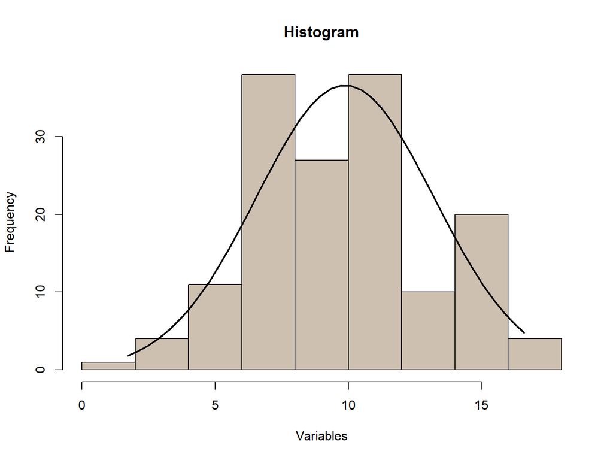

```r
Viz(Data$Wind)
```

```r
skewness(Data$Wind)  #right positive
```

```
[1] 0.05791221
```

The histogram with the density curve of Wind clearly shows that the distribution is normally distributed.

**QQPlot**

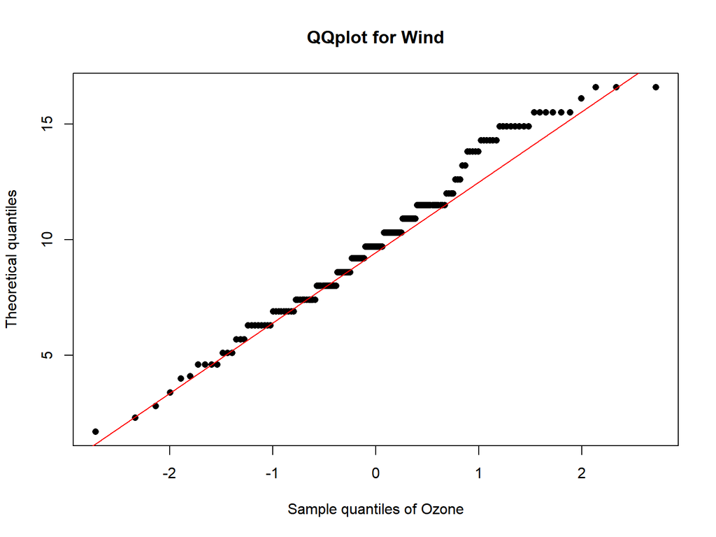

```r
qqnorm(Data$Wind,pch=16,main="QQplot for Wind",xlab="Sample quantiles of Ozone",ylab="Theoretical quantiles")
qqline(Data$Wind, col = 2)
```

**QQPlot** The above QQ plot clearly shows that most of the values lies above the normal line but more or less close to it. So we can interpret that the data is surely from a normal distribution.

**Hypothesis testing:**

```r
shapiro.test(Data$Wind)
```

```
    Shapiro-Wilk normality test

data:  Data$Wind
W = 0.98177, p-value = 0.04044
```

If p is more than .01 {$\alpha$}, we can be 99% {$(1-\alpha)100\%$} certain that the data are normally distributed.

### **For Temp**

**Before Transformation Histogram**

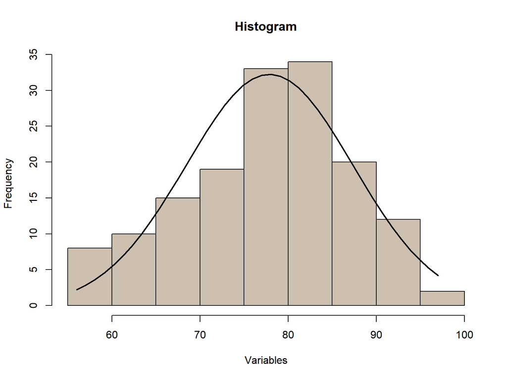

```r
Viz(Data$Temp)
```

```r
skewness(Data$Temp)
```

```
[1] -0.3705073
```

**After Transformation Histogram**

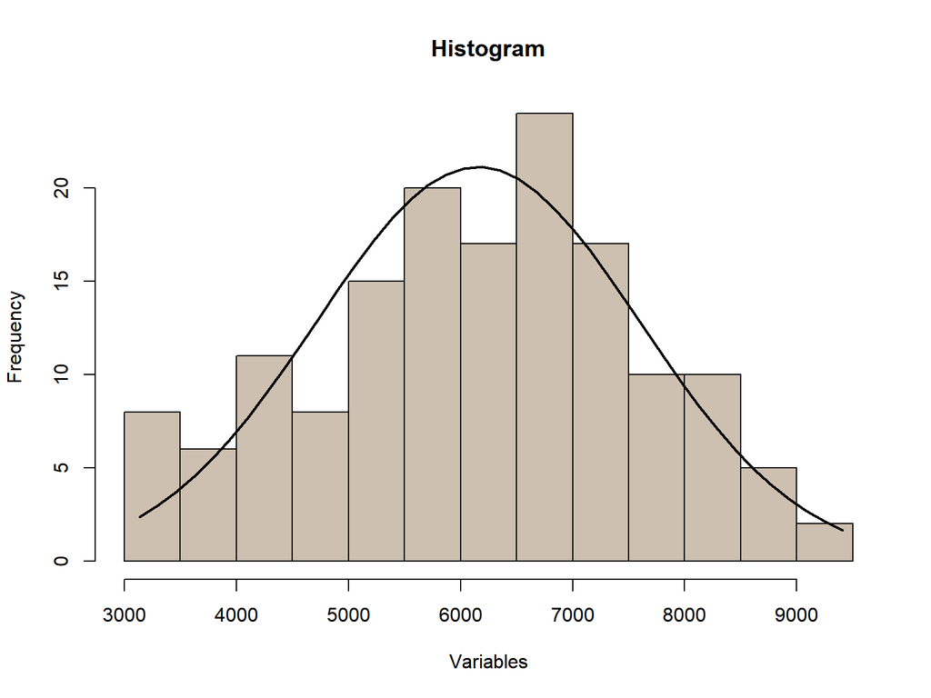

```r
Temp_T <- Data$Temp^2
Viz(Temp_T)
```

```r
skewness(Temp_T)
```

```
[1] -0.1080352
```

After **Square Transformation** the histogram with the density curve of Temp clearly shows that the variable is slightly skewed and so the data is from normal population. Also the skewness is much close to 0.

**QQPlot**

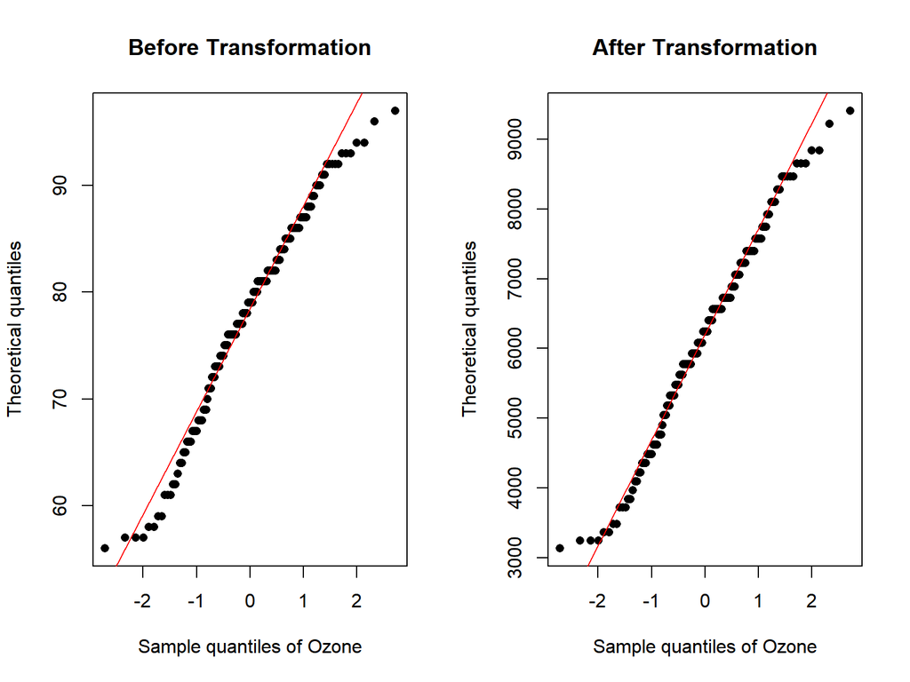

```r
par(mfrow=c(1,2))
qqnorm(Data$Temp,pch=16,main="Before Transformation",xlab="Sample quantiles of Ozone",ylab="Theoretical quantiles")
qqline(Data$Temp, col = 2)
qqnorm(Temp_T,pch=16,main="After Transformation",xlab="Sample quantiles of Ozone",ylab="Theoretical quantiles")
qqline(Temp_T, col = 2)
```

**QQPlot** The above QQ plot clearly shows that most of the values lies above the normal line but more or less close to it. So we can interpret that the data is surely from a normal distribution.

**Hypothesis testing:**

```r
shapiro.test(Temp_T)
```

```
    Shapiro-Wilk normality test

data:  Temp_T
W = 0.98546, p-value = 0.1089
```

If p is more than .01 {$\alpha$}, we can be 99% {$(1-\alpha)100\%$} certain that the data are normally distributed.

```r
Data$Ozone <- Ozone_T
Data$Solar.R <- Solar_T
Data$Temp <- Temp_T
```

## **Scale Transformation**

This transformation is a must if you have data in different scales, this transformation does not change the shape of the variable distribution.

```r
T <- Data[c(5,6)]
Data <- apply(Data[-c(5,6)],2,scale)
Data <- cbind(Data,T)
head(Data,50)
```

|  | Ozone | Solar.R | Wind | Temp | Month | Day |
| --- | --- | --- | --- | --- | --- | --- |
| 1 | 0.384942387 | -0.1997429 | -0.74252405 | -1.15279397 | 5 | 1 |
| 2 | 0.225670508 | -0.9227365 | -0.56248256 | -0.67179029 | 5 | 2 |
| 3 | -1.088657976 | -0.6528854 | 0.81783552 | -0.46969953 | 5 | 3 |
| 4 | -0.611804235 | 1.8173427 | 0.48775946 | -1.59919308 | 5 | 4 |
| 5 | -1.866521575 | -0.6431372 | 1.32795308 | -2.08919396 | 5 | 5 |
| 6 | -0.080456709 | -0.6135015 | 1.50799457 | -1.24484216 | 5 | 6 |
| 7 | -0.318251764 | 1.5380043 | -0.38244107 | -1.33550617 | 5 | 7 |
| 8 | -0.547350827 | -1.0571567 | 1.17791850 | -1.85042235 | 5 | 8 |
| 9 | -1.550728419 | -1.3649245 | 1.68803606 | -1.68432035 | 5 | 9 |
| 10 | -1.088657976 | -0.1496654 | -0.38244107 | -0.96454505 | 5 | 10 |

[output cut: 40 more lines]

Now that the Data has been transformed and made consistent these are very important steps in Exploratory Data Analysis before Model Fitting. The quality and effort invested in data exploration can make a diffrence in building a good model from bad model.